# Spatial variogram

Guillaume Blanchet & Steve Vissault

November 21th, 2019

# Prepare the R environment

We load the packages needed for this practice.

```r
# Spatial
library(sf)
library(sp)
# Manipulation
library(dplyr)
# Analysis
library(gstat)
```

The first step is to load the data from the the CABIN Canadian Aquatic Biomonitoring Network in the Hamilton Harbour. We then want to project in the NAD83 / Ontario MNR Lambert (more accurate and suitable for the study area). If you want to read more about it: http://epsg.io/3161

# Load data

The `.rds` can be load in the R environment using the function `readRDS()`. The file contains an R object: the CABIN data for the Hamilton Harbour.

```r
hamilton <- readRDS("../data/post_process/hamilton_habitat.rds")
# Reproject the spatial data in NAD83 / Ontario MNR Lambert
ham_sf <- st_transform(hamilton, crs = 3161)
```

# Filter the data

```r
ham_sf_2005 <- ham_sf %>%
        filter(Year.Année == 2005 & Variable == "TP")

ham_sf_2005Depth <- ham_sf %>%
        filter(Year.Année == 2005 & Variable == "Depth-Lake")

ham_sf_2005_NoDup <- ham_sf_2005[!duplicated(ham_sf_2005$Site.Site),]

# Transform into an sp object needed for the variogram function
ham_SP_2005 <- as(ham_sf_2005_NoDup, "Spatial")

#---------------------------------------------------
## Another way to work around the duplicated samples
#---------------------------------------------------
ham_sf_2005 <- ham_sf %>%
        filter(Year.Année == 2005 & Variable == "TP")

ham_sf_2005Depth <- ham_sf %>%
        filter(Year.Année == 2005 & Variable == "Depth-Lake")

ham_sf_2005_WithDepth <- ham_sf_2005
ham_sf_2005_WithDepth$depth <- ham_sf_2005Depth$Value.Valeur

# Transform into an sp object needed for the variogram function
ham_SP_2005_DepthSP <- as(ham_sf_2005_WithDepth, "Spatial")
ham_SP_2005_DepthSP@coords <- jitter(ham_SP_2005_DepthSP@coords,factor = 0.015)
```

# Cloud variogram

## Build the cloud variogram

```r
maxDist <- max(dist(coordinates(ham_SP_2005)))
varioCloud <- variogram(Value.Valeur ~ 1,
                   data = ham_SP_2005,
                   cloud= TRUE,
                   cutoff = maxDist)
```

## Plot the cloud variogram

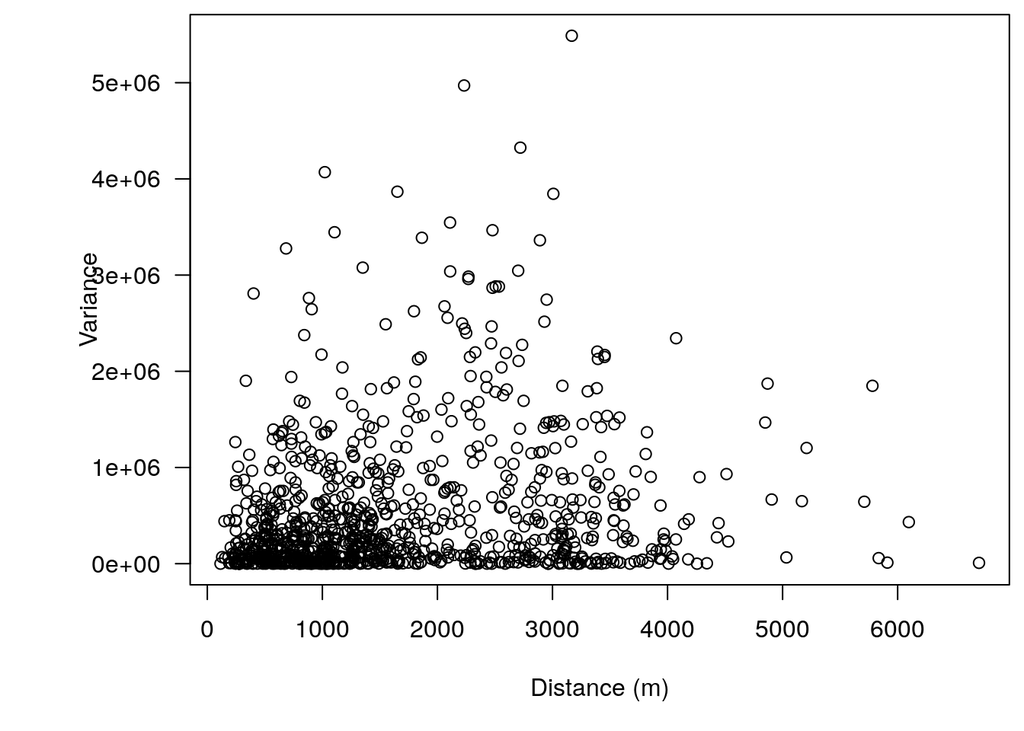

```r
par(mar = c(5,6.5,0.5,0.5))
plot(varioCloud$dist, varioCloud$gamma,
     xlab = "Distance (m)",
     ylab = "Variance",
     las = 1)
```

## Directional variogram

To convert the variogram into a directional one, we have to set the argument `alpha`. We pass a vector of angles through the `alpha` parameters: `c(0, 45, 90, 135)`.

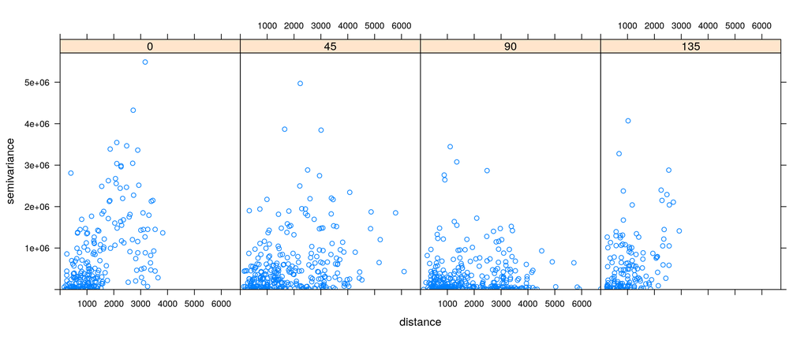

# Empirical variogram

Emprical sometimes referred to sample variogram.

## Step 1 - Study spatial autocorrelation

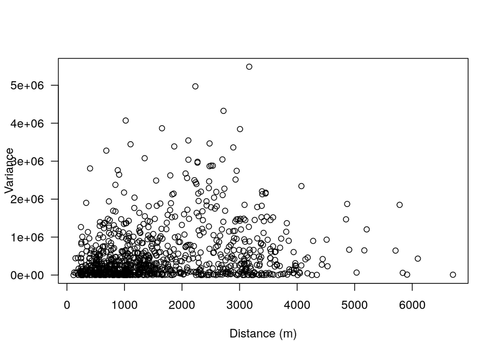

```r
plot(varioCloud$dist, varioCloud$gamma,
     xlab = "Distance (m)",
     ylab = "Variance",
     las = 1)
```

### Visual autocorrelation check

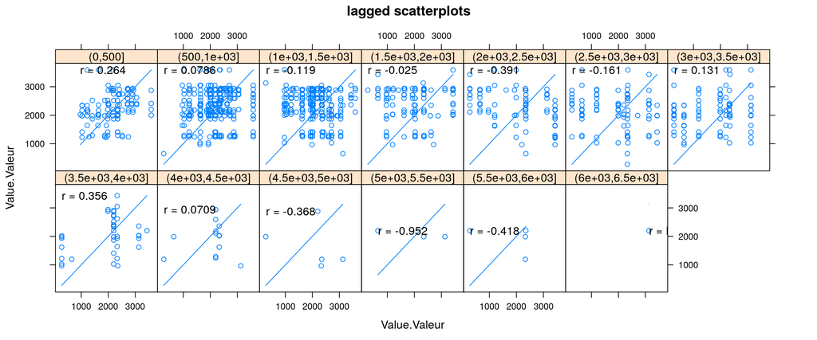

```r
hscat(Value.Valeur ~ 1,
      data = ham_SP_2005,
      breaks = seq(0,maxDist, by = 500))
```

## Step 2 - Cloud variogram

Construct a cloud variogram with a maximum distance of 1500m.

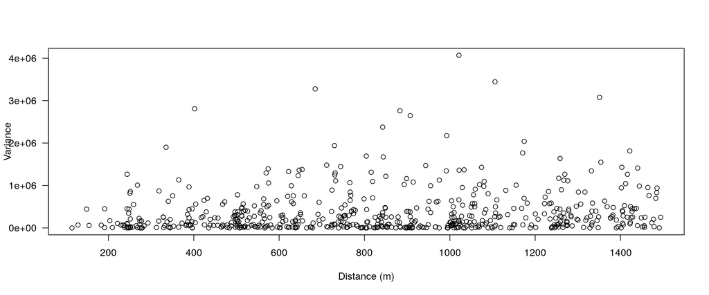

## Step 3 - Check for outliers

Select point pairs by digitizing a region with the mouse (left mouse button adds a point, right mouse button ends)

```r
# This is easier to run outside RStudio as such:
# windows() # For windows users
# quartz() # For mac users

outliers <- plot(varioCloud, digitize = TRUE)
outliers
```

Ids of the row for the pair of points

```
##   head tail
## 1    4    6
## 2    5    6
```

## Step 4 - Remove outlier

```r
ham_SP_2005_clean <- ham_SP_2005[-6,]
```

## Step 5 - Redraw the cloud variogram

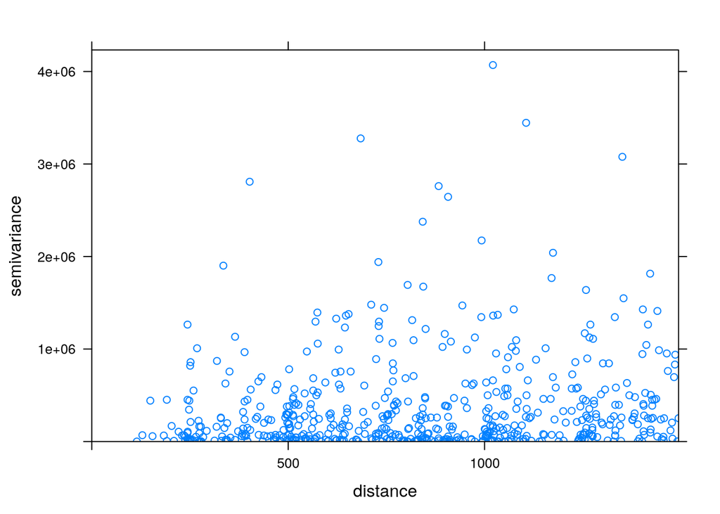

```r
varioCloud <- variogram(Value.Valeur ~ 1, data = ham_SP_2005_clean,
                   cloud= TRUE,cutoff = 1500)
plot(varioCloud)
```

## Step 6 - Define bin limits

```r
binLimit <- c(seq(0,1000,by = 100),
              seq(1200,1500, by = 200))
```

```r
# Construct variogram
varioEmpGood <- variogram(Value.Valeur ~ 1,
                          data = ham_SP_2005_clean,
                          cutoff = 1500,
                          boundaries = binLimit)
```

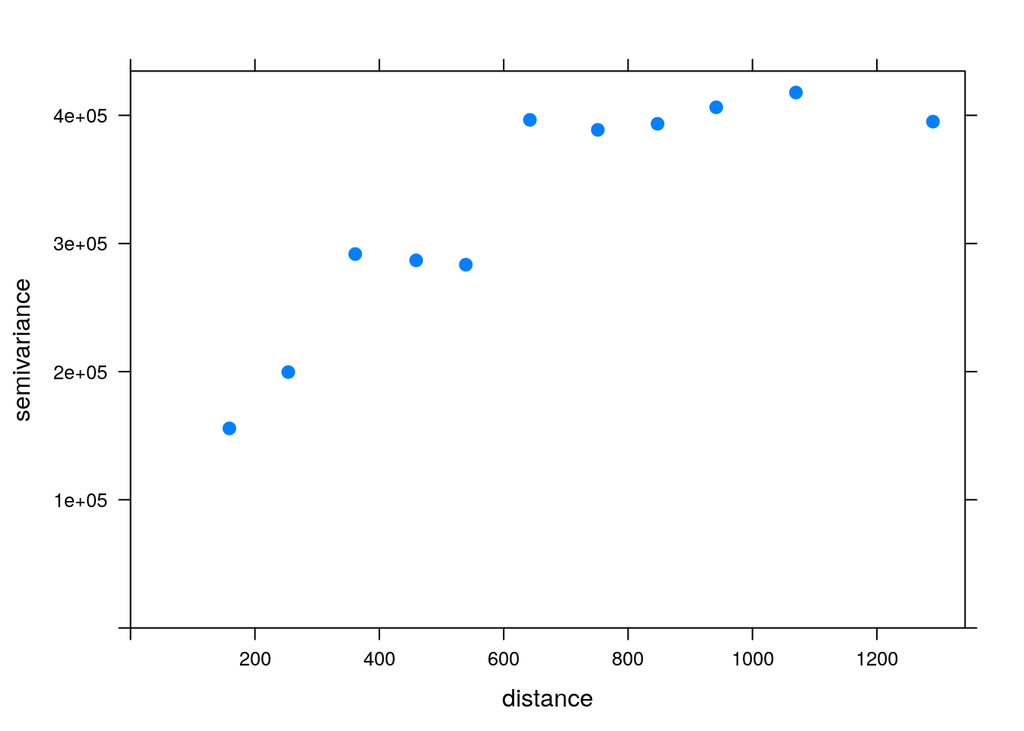

```r
plot(varioEmpGood, cex = 1, pch = 19)
```

# Residual empirical variogram

It is also possible to study the autocorrelation structure in the data **after** accounting for one or more covariates.

In the example below, we evaluate the autocorrelation structure after accounting for sampling effort.

```r
varioEmpResid <- variogram(Value.Valeur ~ SampleNumber.Numérod.échantillon.,
                           data = ham_SP_2005_clean,
                           cutoff = 1500,
                          boundaries = binLimit)
```

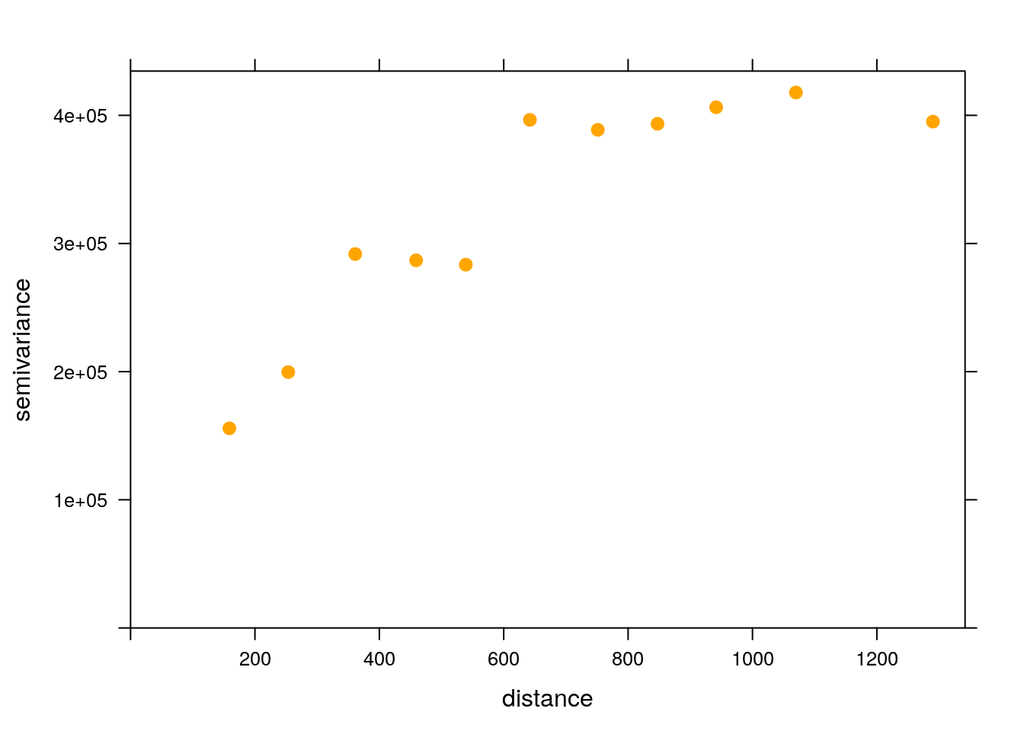

```r
plot(varioEmpResid, cex = 1, pch = 19, col = "orange")
```

# Model variogram

In regard to step 1 and step 2, we choose to fit an exponential model variogram with the restricted maximum likelihood (REML).

```r
# Fit using cloud variogram
modelIni <-  vgm(psill = 4e5, model = "Exp",
                 range = 800, nugget = 50000)

modelVario <- fit.variogram.reml(Value.Valeur ~ 1,
                                 data = ham_SP_2005_clean,
                                 model = modelIni)

# Fit using empirical variogram
modelIni <-  vgm(psill = 3.5e5, model = "Exp",
                 range = 600, nugget = 1e5)

# plot(varioEmpGood,model = modelIni)
#Do this step a few times to make sure you have good starting values

modelVarioEmp <- fit.variogram(varioEmpGood,
                               model = modelIni,
                               fit.method = 7)
```

## Model visualization

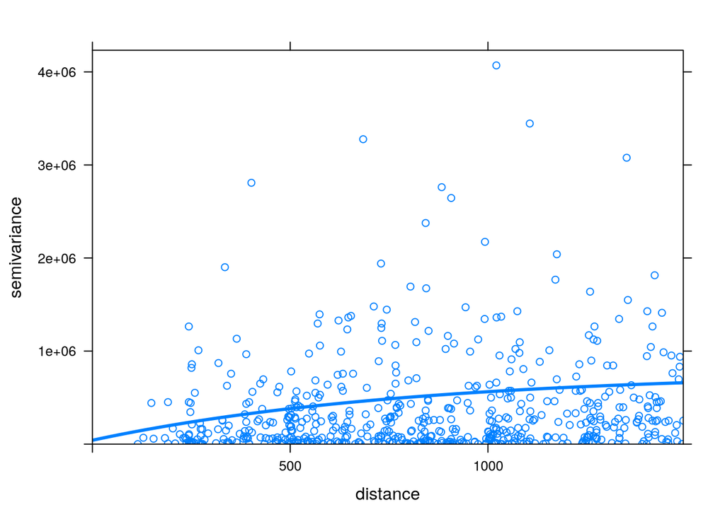

```r
plot(varioCloud, model = modelVario, lwd = 3)
```

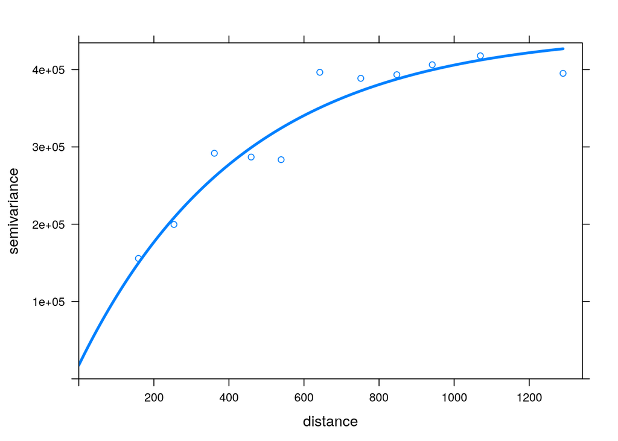

```r
plot(varioEmpGood, model = modelVarioEmp, lwd = 3)
```

# Exercice

1. Build a model variogram using the empirical variogram
- This means using another model variogram fitting method
2. Build a model variogram with another variable
- This may require using another model variogram
3. Build a model variogram on your own data
- Think of the question you want to answer
- The size of your data will influence the choice of model fitting procedure

# Kriging

Using the model variogram defined above we can now build kriging maps

## Step 1 - Define a grid

```r
library(sf)
library(raster)
lake <- st_read("../data/raw/hamilton_harbor.gdb", layer="waterbody_2", quiet = TRUE)

# Align the projections
lake <- st_transform(lake, st_crs(ham_SP_2005_clean))

# Create the reference grid for model projection (using the lake extent)
r_ref <- raster(lake,res=100)
r_ref
```

```
## class      : RasterLayer
## dimensions : 82, 148, 12136  (nrow, ncol, ncell)
## resolution : 100, 100  (x, y)
## extent     : 1341058, 1355858, 11862377, 11870577  (xmin, xmax, ymin, ymax)
## crs        : +proj=lcc +lat_1=44.5 +lat_2=53.5 +lat_0=0 +lon_0=-85 +x_0=930000 +y_0=6430000 +ellps=GRS80 +towgs84=0,0,0,0,0,0,0 +units=m +no_defs
```

As for inverse distance weighting, we build a grid of $100 \times 100$ m.

## Simple kriging

```r
###
# Performing kriging using the interpolate function
###
# Simple kriging
skModel <- gstat(formula = Value.Valeur ~ 1, location = ham_SP_2005_clean,
            model = modelVario, beta = 2)

# Build interpolation map
skMap <- interpolate(object = r_ref, model = skModel, debug = 0)

###
# Performing kriging using the krige function
###

# Organise raster into a dara.frame
r_refDF<-as.data.frame(r_ref, xy = TRUE)

# SpatialPointsDataFrame
coordinates(r_refDF) <- ~ x+ y

# SpatialPixelDataFrame
gridded(r_refDF) <- TRUE

# Add the projection
proj4string(r_refDF) <- crs("+proj=lcc +lat_1=44.5 +lat_2=53.5 +lat_0=0 +lon_0=-85 +x_0=930000 +y_0=6430000 +ellps=GRS80 +towgs84=0,0,0,0,0,0,0 +units=m +no_defs")

# Build our model
skModelKrige <- krige(formula = Value.Valeur ~ 1, location = ham_SP_2005_clean, model = modelVario, beta = 2, newdata = r_refDF)
```

```
## [using simple kriging]
```

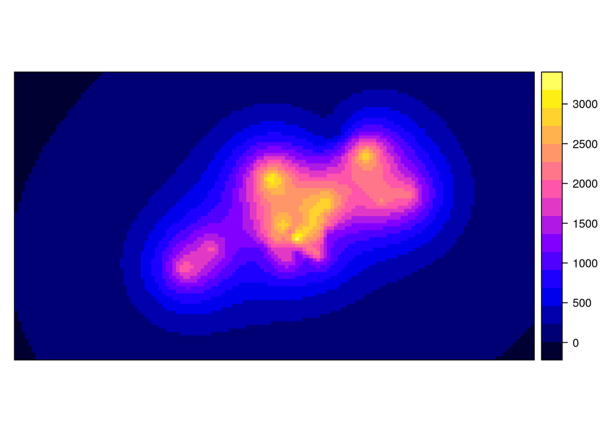

```r
# Plot prediction
spplot(skModelKrige["var1.pred"])
```

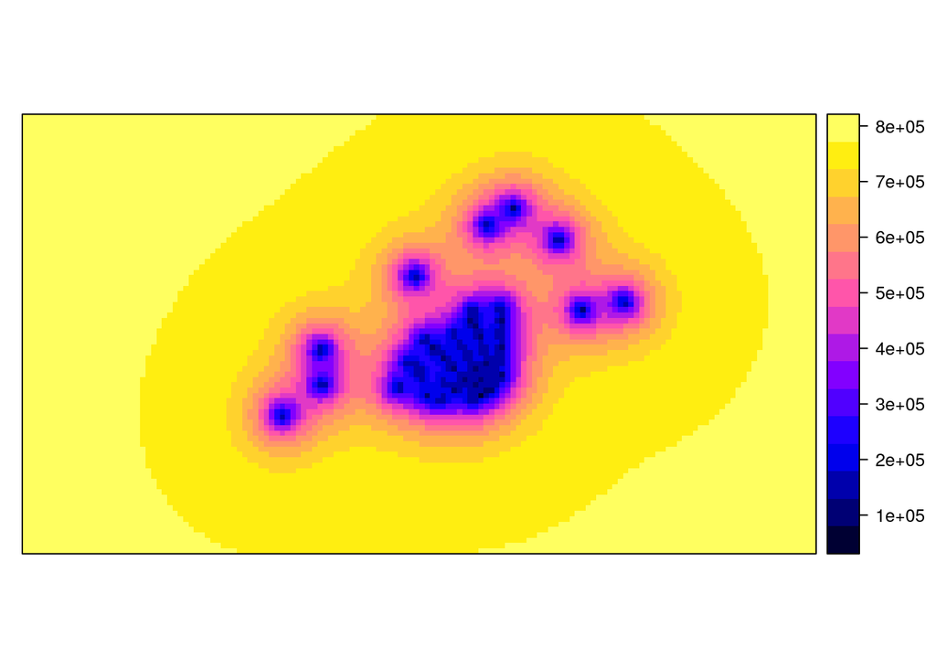

```r
# Plot variation
spplot(skModelKrige["var1.var"])
```

```r
# Building 95% confidence interval around the model
sdsk <- sqrt(skModelKrige$var1.var)
CI.025 <- qnorm(0.025) * sdsk + skModelKrige$var1.pred
CI.975 <- qnorm(0.975) * sdsk + skModelKrige$var1.pred

# Build raster for 95% confidence interval
skMap$CI.025 <- CI.025
skMap$CI.975 <- CI.975
```

### Draw the map

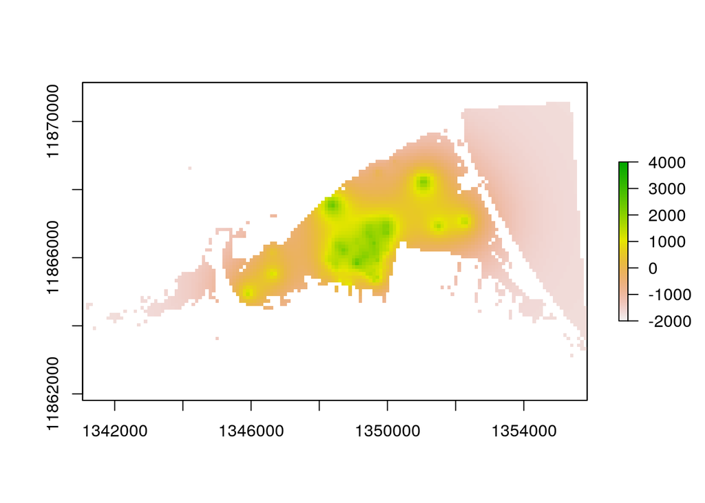

```r
library(mapview)
# Mask
skMapMask <- mask(skMap, lake)
plot(skMapMask$CI.025, zlim = c(-2000, 4000))
```

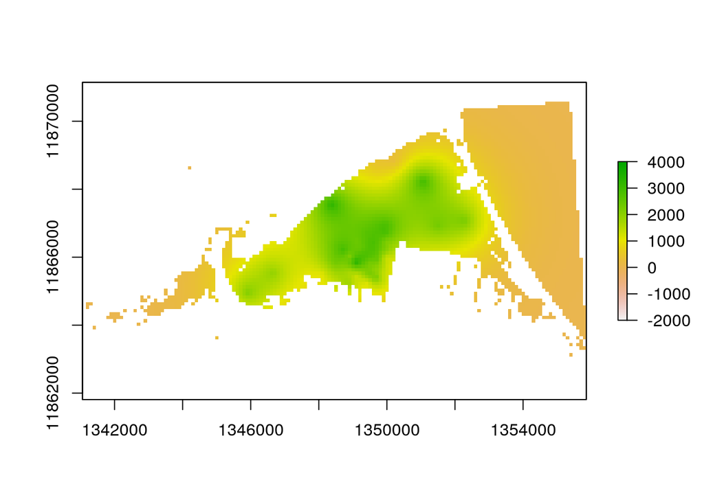

```r
plot(skMapMask$var1.pred, zlim = c(-2000, 4000))
```

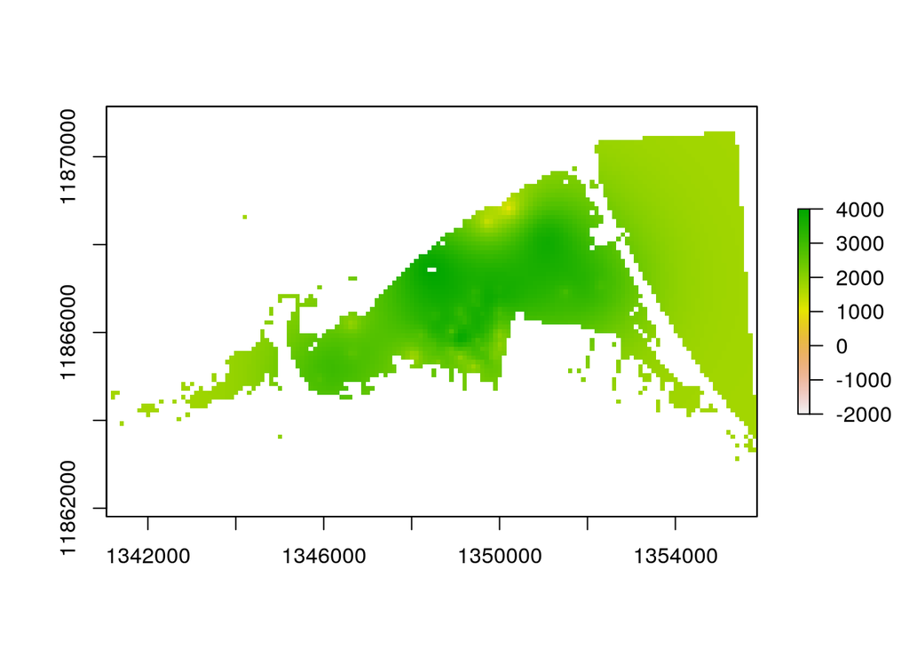

```r
plot(skMapMask$CI.975, zlim = c(-2000, 4000))
```

## Ordinary kriging

```r
# Ordinary kriging
okModel <- gstat(formula = Value.Valeur ~ 1, location = ham_SP_2005_clean,
            model = modelVario)

# Build interpolation map
okMap <- interpolate(object = r_ref, model = okModel, debug = 0)
```

### Draw the map

```r
library(mapview)
# Mask
okMapMask <- mask(okMap, lake)
mapview(okMapMask)
```

[interactive chart not shown]

# Exercice

1. Build a kriging maps with another variable
- This means using another model variogram
2. Perform universal kriging
3. Build a kriging maps on your own data
- Think of the question you want to answer
- The size of your data will influence the choice of model fitting procedure